# Algorithm Beginner Class 8 Lecture - Queue & Linked List

2018/6/14

# Queue

## Popular Interview Question 1

How could we implement a queue by using two stacks?

Operations: `offer(3)`, `offer(2)`, `poll()`, `offer(1)`, `peek()`, `offer(6)`, `poll()`, `poll()`

> `offer(3)`  
> In-stack: 3  
> Out-stack:

> `offer(2)`  
> In-stack: 3, 2  
> Out-stack:

> `reverse`  
> In-stack:  
> Out-stack: 2, 3

> `poll()=3`  
> In-stack:  
> Out-stack: 2

> `offer(1)`  
> In-stack: 1  
> Out-stack: 2

> `peek()=2`  
> In-stack: 1  
> Out-stack: 2

> `offer(6)`  
> In-stack: 1, 6  
> Out-stack: 2

> `poll()=2`  
> In-stack: 1, 6  
> Out-stack:

> `reverse`  
> In-stack:  
> Out-stack: 6, 1

> `poll()=1`  
> In-stack:  
> Out-stack: 6

```java
package laioffer;
import java.util.*;
public class Test {
  public static void main(String[] args) {
    //
  }
}

//assume Myqueue is used for storing ints.
class MyQueue {
  Deque<Integer> in = new LinkedList<>();
  Deque<Integer> out = new LinkedList<>();

  public void offer(int value) {
    in.push(value);
  }

  private void shuffleIf Necessary() {
    //out-stack裡面沒有數了就要倒騰(reverse)
    if (out.isEmpty()) {
      while (!in.isEmpty()) {
        out.push(in.pop());
      }
    }
  }

  //Interger is a wrapper of int; it is essentially int + null

  public Interger poll() {
    shuffleIfNecessary();
    //out-stack裡面沒數倒騰后in-stack里也沒有，就要返回null
    if (out.isEmpty()) {
      return null;
    }
    return out.pop();
  }

  public Interger peek() {
    shuffleIfNecessary();
    //out-stack裡面沒數倒騰后in-stack里也沒有，就要返回null
    if (out.isEmpty()) {
      return null;
    }
    return out.peek();
  }

  public int size() {
    return in.size() + out.size();
  }

  public boolean isEmpty() {
    return in.isEmpty() && out.isEmpty();
  }
}
```

```java
import java.util.*;
public class Solution {
  Deque<Integer> in;
  Deque<Integer> out;
  public Solution {
    in = new LinkedList<Integer>();
    out = new LinkedList<>();
  }
  private void shuffleIfNecessary() {
    if (out.isEmpty()) {
      while (!in.isEmpty()) {
        out.push(in.pop());
      }
    }
  }
  public Interger poll() {
    shuffleIfNecessary();
    if (out.isEmpty()) {
      return null;
    }
    return out.pop();
  }
  public void offer(int element) {
    in.push(element);
  }
  public Interger peek() {
    shuffleIfNecessary();
    if (out.isEmpty()) {
      return null;
    }
    return out.peek();
  }
  public int size() {
    return in.size() + out.size();
  }
  public boolean isEmpty() {
    return in.isEmpty() && out.isEmpty();
  }
}
```

Time complexity:

- `offer()`: O(1)
- `size()`: O(1)
- `isEmpty()`: O(1)

Amortized time complexity:

- `poll()`: O(1)
- `peek()`: O(1)

Space complexity: O(1)

## Popular Interview Question 2

How to implement the **min()** function when **using stack** with time complexity O(1)?

7, 2, 5, 3, 8, 2  
`peek()`: O(1)  
`pop()`: O(1)  
`push()`: O(1)  
`min()`: O(1)

Stack: 7, 2, 5, 3, 8, 2  
Min: 7, 2, 2, 2, 2, 2

`push(1)`  
Stack: 7, 2, 5, 3, 8, 2, 1  
Min: 7, 2, 2, 2, 2, 2, 1

```java
package laioffer;
import java.util.*;
public class Test {
  public static void main(String[] args) {
    //
  }
}

class MinStack() {
  Deque<Integer> stack = new LinkedList<>();
  Deque<Integer> min = new LinkedList<>();

  public void push(int value) {
    stack.push(value);
    if (min.isEmpty() || value <= min.peek()) {
      min.push(value);
    }
  }

  public Interger pop() {
    if (stack.isEmpty()) {
      return null;
    }
    int ret = stack.pop();
    if (ret == min.peak()) {
      min.pop();
    }
    return ret;
  }

  public Interger peek() {
    if (stack.isEmpty()) {
      return null;
    }
    return stack.peek();
  }

  public int size() {
    return stack.size();
  }

  public boolean isEmpty() {
    return stack.isEmpty();
  }

  public Interger min() {
    if (min.isEmpty()) {
      return null;
    }
    return min.peek();
  }
}
```

```java
public class Solution {
  Deque<Integer> stack;
  Deque<Integer> minStack;

  public Solution() {
    stack = new LinkedList<>();
    minStack = new LinkedList<>();
  }
  public Interger pop() {
    if (stack.isEmpty()) {
      return null;
    }
    int t = stack.pop();
    if (t == minStack.peak()) {
      minStack.pop();
    }
    return t;
  }
  public void push(int element) {
    stack.push(element);
    if (minStack.isEmpty() || element <= minStack.peek()) {
      minStack.push(element);
    }
  }
  public Interger peek() {
    if (stack.isEmpty()) {
      return null;
    }
    return stack.peek();
  }
  public Interger min() {
    if (minStack.isEmpty()) {
      return null;
    }
    return minStack.peek();
  }
}
```

# Linked List

**Memory**

| 0XFFFF0000 | 0XFFFF0004 | 0XFFFF0008 | 0XFFFF000C | 0XFFFF0010 | - |
| --- | --- | --- | --- | --- | --- |
| a[0] | a[1] | a[2] | - | - | - |

**Randon Access**

`int[] a = new int[1000];`  
`int x = a[700]; address_x = address(a) + 700 * 4;`

```java
package laioffer;
import java.util.*;

public class Test {
  public static void main(String[] args) {
    ListNode head = new ListNode(0);
    ListNode cur = head;
    for (int i = 1; i < 1000; i = i + 1) {
      cur.next = new ListNode(i);
      cur = cur.next;
    }
  }
}

class ListNode {
  public ListNode(int x) {//Constructor!!
    value = x;
  }

  int value;  //the storage
  ListNode next;  //it is reference, or, it is an address
  ListNode prev;  //points to the previous node
}
```

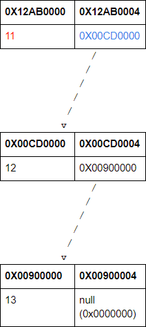

**Key points:**

1. If there is a linked list with 1000 elements, and I want to find the 700th element; When you want to access value/next of a ListNode, make sure it is not null pointer
2. Never ever lose the control of the head pointer of the LinkedList

## Popular Interview Question 1

How to reverse a linked list?

```java
package laioffer;
import java.util.*;

public class Test {
  public static void main(String[] args) {
    ListNode head = new ListNode(0);
    ListNode cur = head;
    for (int i = 1; i < 1000; i = i + 1) {
      cur.next = new ListNode(i);
      cur = cur.next;
    }

    ListNode newHead = reverse(head);
  }

  public static ListNode reverse(ListNode head) {
    if (head == null || head.next == null) {
      return head;
    }
    ListNode p = pull, c = head, n;
    while(c != null) {
      ListNode n = c.next;

      c.next = p;

      p = c;
      c = n;
    }
    return p;
  }
}

class ListNode {
  public ListNode(int x) {//Constructor!!
    value = x;
  }

  int value;  //the storage
  ListNode next;  //it is reference, or, it is an address
}
```

```java
public class Solution {
  public ListNode reverse(ListNode head) {
    ListNode prev = null;
    ListNode cur = head;
    ListNode next = null;
    while (cur != null) {
      next = cur.next;
      cur.next = prev;
      prev = cur;
      cur = next;
    }
    return prev;
  }
}
```

Time complexity: O(n)  
Space complexity: O(1)